# Trabajo grupal - Data Science

## Evaluación del modelo regresor lineal

A continuación, evaluamos el modelo lineal ponderado cuantitativamente.

```r
library(dplyr)
library(ggplot2)

#métricas
resid_lm   <- df_modelo$susp_rate - df_modelo$pred_lm
rmse_lm    <- sqrt(mean(resid_lm^2, na.rm = TRUE))
mae_lm     <- mean(abs(resid_lm), na.rm = TRUE)
r2_lm      <- summary(m_lm)$r.squared
adj_r2_lm  <- summary(m_lm)$adj.r.squared


cat("   EVALUACIÓN DEL MODELO LINEAL PONDERADO\n")
```

```
##    EVALUACIÓN DEL MODELO LINEAL PONDERADO
```

```r
cat(sprintf("  R²:          %.4f\n", r2_lm))
```

```
##   R²:          0.9770
```

```r
cat(sprintf("  R² ajustado: %.4f\n", adj_r2_lm))
```

```
##   R² ajustado: 0.9730
```

```r
cat(sprintf("  RMSE:        %.4f\n", rmse_lm))
```

```
##   RMSE:        0.0108
```

```r
cat(sprintf("  MAE:         %.4f\n", mae_lm))
```

```
##   MAE:         0.0078
```

```r
# Tabla resumen
tabla_eval <- data.frame(
  Metrica = c("R²", "R² ajustado", "RMSE", "MAE"),
  Valor   = c(r2_lm, adj_r2_lm, rmse_lm, mae_lm)
)
tabla_eval
```

| Metrica | Valor |
| --- | --- |
| R² | 0.977012707 |
| R² ajustado | 0.973009302 |
| RMSE | 0.010790202 |
| MAE | 0.007839118 |

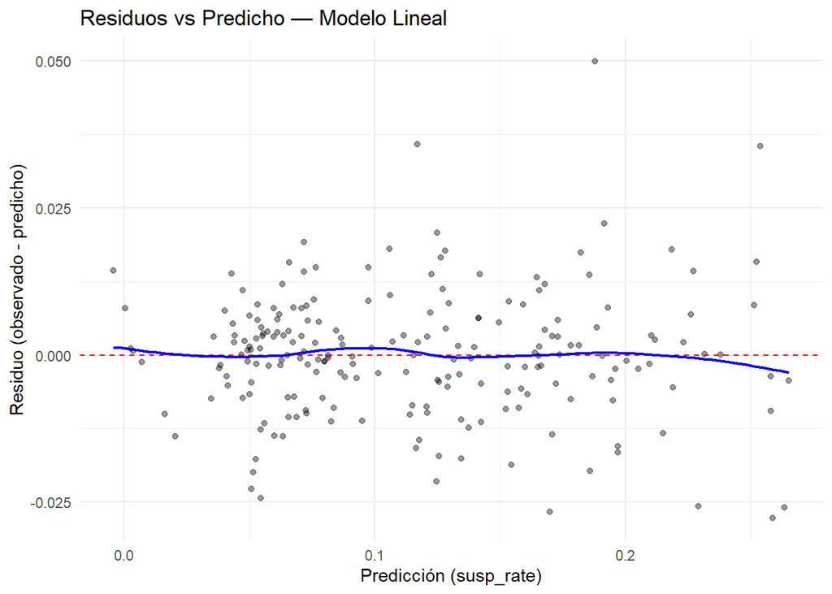

```r
#vemos los residuos
df_modelo$resid_lm <- resid_lm

#residuos vs predicho
ggplot(df_modelo, aes(x = pred_lm, y = resid_lm)) +
  geom_point(alpha = 0.4) +
  geom_hline(yintercept = 0, linetype = "dashed", color = "red") +
  geom_smooth(method = "loess", se = FALSE, color = "blue", linewidth = 0.8) +
  labs(
    title = "Residuos vs Predicho — Modelo Lineal",
    x = "Predicción (susp_rate)",
    y = "Residuo (observado - predicho)"
  ) +
  theme_minimal()
```

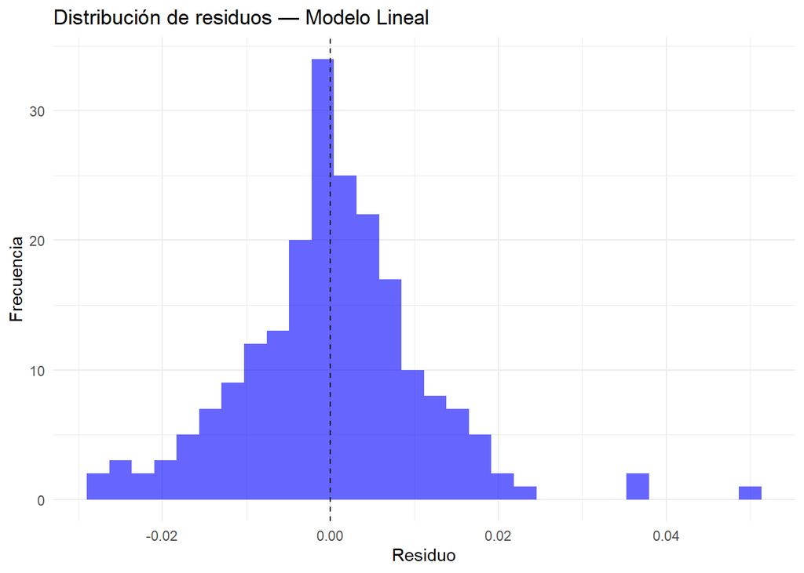

```r
#histograma de residuos
ggplot(data.frame(residuo = resid_lm), aes(x = residuo)) +
  geom_histogram(bins = 30, fill = "blue", alpha = 0.6) +
  geom_vline(xintercept = 0, linetype = "dashed") +
  labs(
    title = "Distribución de residuos — Modelo Lineal",
    x = "Residuo", y = "Frecuencia"
  ) +
  theme_minimal()
```

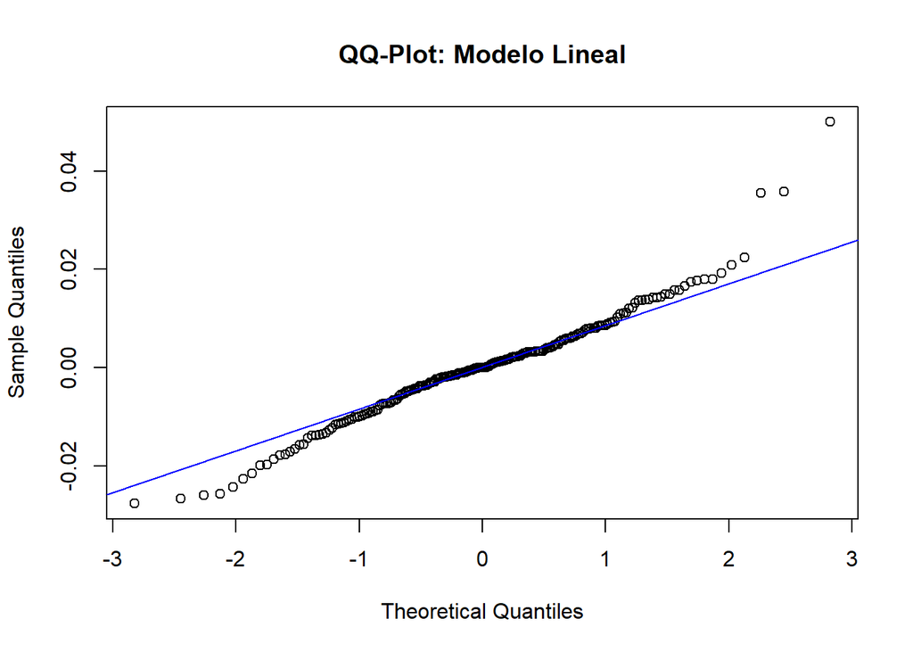

```r
#QQ-plot
qqnorm(resid_lm, main = "QQ-Plot: Modelo Lineal")
qqline(resid_lm, col = "blue")
```

```r
# Coeficiente de np_rate
cat("\n=== EFECTO DE np_rate ===\n")
```

```
##
## === EFECTO DE np_rate ===
```

```r
cat(sprintf("Coef = %.4f (por cada +1pp de NP, susp_rate cambia %.2f pp)\n",
            coef(m_lm)["np_rate"], 100 * coef(m_lm)["np_rate"]))
```

```
## Coef = 0.6089 (por cada +1pp de NP, susp_rate cambia 60.89 pp)
```

El modelo tiene un R² de 0.977 y un R² ajustado de 0.973, lo que indica un excelente ajuste a los datos. El RMSE de 0.0108 y el MAE de 0.0078 son muy bajos, lo que sugiere que el modelo realiza predicciones precisas. En resumen, el modelo es muy efectivo y preciso.

# Conclusiones finales

El análisis realizado sobre los datos académicos de la Universidad de Sevilla entre 2017 y 2024 permite responder con claridad a la pregunta central del trabajo.

**El porcentaje de no presentados no puede considerarse un indicador de dificultad intrínseca de una asignatura, pero sí funciona como un indicador fiable de riesgo académico.** La dificultad es una propiedad de la asignatura, mientras que el riesgo académico es una señal observable que anticipa peores resultados sin explicar por qué se producen.

La evidencia que sostiene esta conclusión es consistente a todos los niveles de análisis. A nivel global, las correlaciones de Spearman muestran una asociación moderada pero robusta entre el porcentaje de no presentados y el rendimiento de quienes sí se examinan (rho ≈ -0.42 para aprobados y rho ≈ +0.43 para suspensos, ambos con p < 2.2e-16). A nivel de centro, el patrón se mantiene en casi todos los casos y el análisis temporal confirma que los años con más no presentados son también, en promedio, los años con más suspensos. A nivel de asignatura, el 76% de las asignaturas que superan los filtros de robustez muestran correlaciones con el signo esperado. A nivel de rama, el efecto es homogéneo entre Artes y Humanidades, Ciencias, Ciencias de la Salud, Ciencias Sociales e Ingeniería, con la única excepción sistemática del Posgrado.

Las reglas de asociación refuerzan este diagnóstico: la combinación rama Ingeniería + tamaño mediano + aprobados medios predice NP alto con un 82.7% de confianza (lift = 3.90), lo que convierte ese perfil en un criterio de alerta que la institución podría activar.

**Implicación práctica principal:** la Universidad de Sevilla podría incorporar el porcentaje de no presentados como variable de alerta temprana en sus sistemas de seguimiento de titulaciones, priorizando la intervención en los centros con mayor efecto normalizado (Ingeniería de Edificación, Farmacia, Turismo y Finanzas) y en asignaturas de la rama de Ingeniería con tamaño mediano y rendimiento medio, que es la combinación que las reglas de asociación identifican como de mayor riesgo.

**Limitación principal:** la relación observada es asociativa, no causal. Factores no recogidos en los datos, como cambios en el sistema de evaluación, el impacto del COVID-19 en los cursos 2019-21 o el perfil socioeconómico del alumnado, pueden explicar parte de la variación observada. Para convertir este análisis en una herramienta de gestión sólida sería necesario incorporar los datos de satisfacción del tercer dataset disponible y cruzarlos con las tasas de abandono por titulación, lo que permitiría distinguir si el problema de la no presentación es de motivación, de dificultad percibida o de circunstancias externas al proceso de aprendizaje.